# Test a Perceptual Phenomenon

### Analyzing the Stroop Effect

Perform the analysis in the space below. Remember to follow [the instructions](https://docs.google.com/document/d/1-OkpZLjG_kX9J6LIQ5IltsqMzVWjh36QpnP2RYpVdPU/pub?embedded=True) and review the [project rubric](https://review.udacity.com/#!/rubrics/71/view) before submitting. Once you've completed the analysis and write-up, download this file as a PDF or HTML file, upload that PDF/HTML into the workspace here (click on the orange Jupyter icon in the upper left then Upload), then use the Submit Project button at the bottom of this page. This will create a zip file containing both this .ipynb doc and the PDF/HTML doc that will be submitted for your project.

(1) What is the independent variable? What is the dependent variable?

The independent variable is the congruence between the color of the words and what the word says. The dependent variable is the time to read the color of the words, regardless of what the word say.

(2) What is an appropriate set of hypotheses for this task? Specify your null and alternative hypotheses, and clearly define any notation used. Justify your choices.

My hypotheses is that it takes more time to read the color of the words if the color of the words and what the words say are not matching. Therefore, my null hypothesis and alternative hypothesis are: +Null hypothesis (H0): the congruence between the color of the words and what the words say doesn’t affect the time to read the color of the words. The average time between congruent and incongruent group is the same (μ1= μ2). +Alternative hypothesis (H1): the congruence between the color of the words of what the words says affects the time to read the color of the words. The average time between congruent and incongruent group is statistically different (μ1≠ μ2).

I will use paired t-test to test my null hypothesis because I want to see if how the congruence between the color and the meaning of the words affects the reading time of the same group. That one group was tested to get both reading time for congruence and incongruence data set.

(3) Report some descriptive statistics regarding this dataset. Include at least one measure of central tendency and at least one measure of variability. The name of the data file is 'stroopdata.csv'.

```python
# Perform the analysis here
import pandas as pd
import scipy.stats as stats
data = pd.read_csv("stroopdata.csv")
data = pd.DataFrame(data)
mean_Congruent= data['Congruent'].mean()
mean_Incongruent= data['Incongruent'].mean()
stdev_Congruent= data['Congruent'].std()
stdev_Incongruent= data['Incongruent'].std()
print('The average time and standard of deviation for Congruent group are {} seconds and {} seconds'.format(round(mean_Congruent), round(stdev_Congruent)))
print('The average time and standard of deviationfor Incongruent group are {} seconds and {} seconds'.format(round(mean_Incongruent), round(stdev_Incongruent)))
data.describe()
```

```
The average time and standard of deviation for Congruent group are 14.0 seconds and 4.0 seconds
The average time and standard of deviationfor Incongruent group are 22.0 seconds and 5.0 seconds
```

|  | Congruent | Incongruent |
| --- | --- | --- |
| count | 24.000000 | 24.000000 |
| mean | 14.051125 | 22.015917 |
| std | 3.559358 | 4.797057 |
| min | 8.630000 | 15.687000 |
| 25% | 11.895250 | 18.716750 |
| 50% | 14.356500 | 21.017500 |
| 75% | 16.200750 | 24.051500 |
| max | 22.328000 | 35.255000 |

(4) Provide one or two visualizations that show the distribution of the sample data. Write one or two sentences noting what you observe about the plot or plots.

[output not shown]

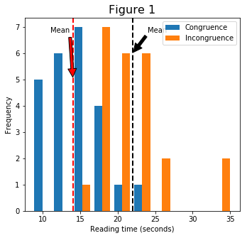

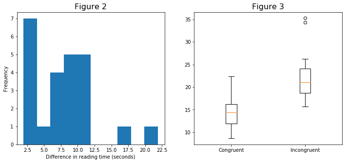

```python
# Build the visualizations
from matplotlib import pyplot as plt
Congruent = data['Congruent']
Incongruent = data['Incongruent']
Difference = data['Incongruent'] - data['Congruent']
plt.figure(1,figsize=(25,5))
plt.subplot(141)
plt.hist([Congruent, Incongruent], label=['Congruence', 'Incongruence'])
plt.title('Figure 1', fontsize=16)
plt.legend(loc='upper right')
plt.axvline(mean_Congruent, color = 'red', linestyle='dashed', linewidth=2)
plt.annotate('Mean', xy=(mean_Congruent, 5), xytext=(mean_Congruent-3, 6.8),
            arrowprops=dict(facecolor='red', shrink=0.05),
            )
plt.axvline(mean_Incongruent, color = 'black', linestyle='dashed', linewidth=2)
plt.annotate('Mean', xy=(mean_Incongruent, 6), xytext=(mean_Incongruent+2, 6.8),
            arrowprops=dict(facecolor='black', shrink=0.05),
            )
plt.xlabel('Reading time (seconds)')
plt.ylabel('Frequency')
plt.figure(2, figsize=(25,5))
plt.subplot(142)
plt.hist(Difference)
plt.title('Figure 2', fontsize=16)
plt.xlabel('Difference in reading time (seconds)')
plt.ylabel('Frequency')
plt.subplot(143)
plt.boxplot([Congruent, Incongruent])
plt.title('Figure 3', fontsize=16)
plt.xticks([1, 2], ['Congruent', 'Incongruent'])
```

(5) Now, perform the statistical test and report your results. What is your confidence level or Type I error associated with your test? What is your conclusion regarding the hypotheses you set up? Did the results match up with your expectations? **Hint:** Think about what is being measured on each individual, and what statistic best captures how an individual reacts in each environment.

```python
# Perform the statistical test here
#Testing assumption for normal distribution.
print(stats.shapiro(Difference))

#Statistical Test
#Mannwhiteney U-test for non-normal distribute
print(stats.mannwhitneyu(Incongruent, Congruent))
#Paired-sample T-test
stats.ttest_rel(Incongruent, Congruent)
```

```
(0.9104195833206177, 0.036017220467329025)
MannwhitneyuResult(statistic=37.0, pvalue=1.2007625250896612e-07)
```

```
Ttest_relResult(statistic=8.020706944109957, pvalue=4.1030005857111781e-08)
```

The confidence level is 5% or alpha is 0.05. That means there are 5% probability that I will reject a null hypothesis incorrectly I use Shapiro to numerically test for normal distribution for difference in reading time Null hypothesis: the difference in reading time data is normally distributed: Alternative hypothesis: the difference in reading time data is not normally distributed The p-value for Shapiro is smaller than alpha. Therefore, the null hypothesis is rejected. However, the p-value is really close to alpha so the skewness is not too severe. We can assume that the data is almost normally distributed

Both p-values for Mann-Whitney U-test and T-test are less than alpha. So we can reject the null hypothesis that the congruence between the color of the words and what the words say doesn’t affect the time to read the color of the words

Conclusion: Both Mann-Whitney U-test and paired sample T-test show that there is a statistically different between the congruence and incongruence group. Since the mean between the congruence and incongruence group is positive, it shows that the reading time increases when the condition is switched from congruence to incongruence. In another word, the incongruence between the color and the meaning of the word increases the reading time.

(6) Optional: What do you think is responsible for the effects observed? Can you think of an alternative or similar task that would result in a similar effect? Some research about the problem will be helpful for thinking about these two questions!

The interference occurs between word reading and color naming is the responsible for the effects observed. We intuitively would read the word first instead of reading the true color of the words. So the brain needs to block the first path (word reading) before doing the second path(reading the color of the words) and that delays the processing time.

Another alternative that would result in a similar effect is that asking someone to type a document while engaging in a conversation. Either the time to type the document will increase or the time to reply to an answer will increase.